# Binary classification

Jindra

11/27/2017

### Setup

```r
library(mlbench)
library(ggplot2)
library(dplyr)
data("BreastCancer")
```

### Binary classification (logistic regression)

```r
BreastCancer %>% head
```

```
##        Id Cl.thickness Cell.size Cell.shape Marg.adhesion Epith.c.size
## 1 1000025            5         1          1             1            2
## 2 1002945            5         4          4             5            7
## 3 1015425            3         1          1             1            2
## 4 1016277            6         8          8             1            3
## 5 1017023            4         1          1             3            2
## 6 1017122            8        10         10             8            7
##   Bare.nuclei Bl.cromatin Normal.nucleoli Mitoses     Class
## 1           1           3               1       1    benign
## 2          10           3               2       1    benign
## 3           2           3               1       1    benign
## 4           4           3               7       1    benign
## 5           1           3               1       1    benign
## 6          10           9               7       1 malignant
```

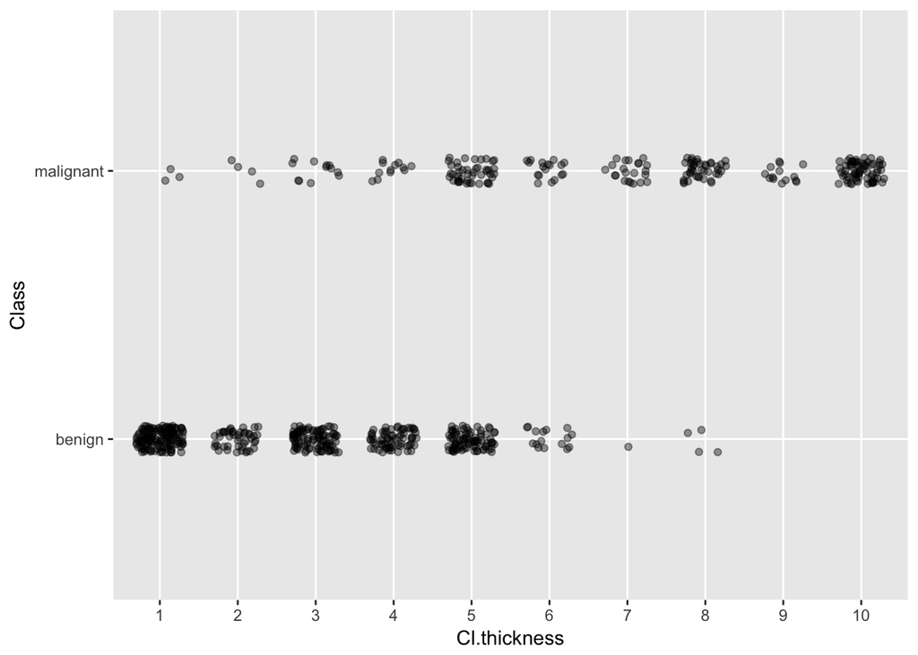

```r
BreastCancer %>% ggplot(aes(x = Cl.thickness, y = Class)) +
  geom_jitter(height = 0.05, width = 0.3, alpha = 0.4)
```

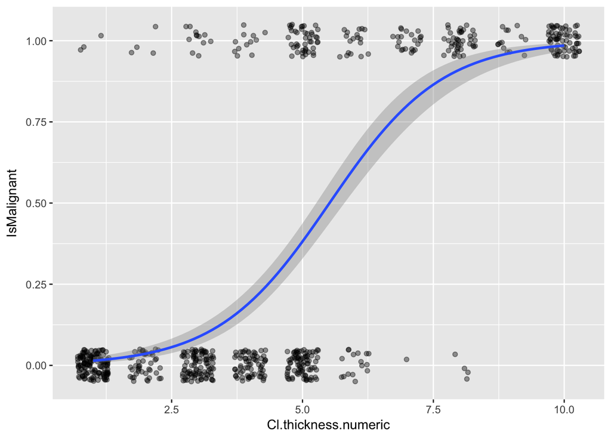

```r
BreastCancer %>%
  mutate(Cl.thickness.numeric = as.numeric(as.character(Cl.thickness))) %>%
  mutate(IsMalignant = ifelse(Class == "benign",0 ,1)) %>%
  ggplot(aes(x = Cl.thickness.numeric, y = IsMalignant)) +
  geom_jitter(height = 0.05, width = 0.3, alpha = 0.4) +
  geom_smooth(method = "glm",
              method.args = list(family = "binomial"))
```

```r
#To actually get the fitted object
BreastCancer %>%
  mutate(Cl.thickness.numeric = as.numeric(as.character(Cl.thickness))) %>%
  mutate(IsMalignant = ifelse(Class == "benign",0 ,1)) %>%
  glm(IsMalignant ~ Cl.thickness.numeric,
      family = "binomial",
      data = .)
```

```
##
## Call:  glm(formula = IsMalignant ~ Cl.thickness.numeric, family = "binomial",
##     data = .)
##
## Coefficients:
##          (Intercept)  Cl.thickness.numeric
##              -5.1602                0.9355
##
## Degrees of Freedom: 698 Total (i.e. Null);  697 Residual
## Null Deviance:       900.5
## Residual Deviance: 464.1     AIC: 468.1
```

### Model matrices and formulas

When we fit a line for single x and y values we are actually also working with fitting a vector because we have both the x values and the intercept to fit. That is why the model has two parameters, θ 0 and θ 0. For each x value, we are actually using the vector (1, x) where the 1 is used to fit the intercept.

```r
cars %>%
  model.matrix(dist ~ speed, data = .) %>%
  head(5)
```

```
##   (Intercept) speed
## 1           1     4
## 2           1     4
## 3           1     7
## 4           1     7
## 5           1     8
```

```r
#remove the intercept
cars %>%
  model.matrix(dist ~ speed - 1, data = .) %>%
  head(5)
```

```
##   speed
## 1     4
## 2     4
## 3     7
## 4     7
## 5     8
```

If you want to fit more than one parameter, no problem. You just give write y ∼ x + z and the model matrix will have 3 columns. So if we wanted to fit the breast cancer data to both cell thickness and cell size, we can do that just by adding both explanatory variables in the formula

```r
BreastCancer %>%
  mutate(Cl.thickness.numeric = as.numeric(as.character(Cl.thickness)),
         Cell.size.numeric = as.numeric(as.character(Cell.size))) %>%
  mutate(IsMalignant = ifelse(Class == "benign", 0, 1)) %>%
  model.matrix(IsMalignant ~ Cl.thickness.numeric + Cell.size.numeric,
               data = .) %>%
  head(5)
```

```
##   (Intercept) Cl.thickness.numeric Cell.size.numeric
## 1           1                    5                 1
## 2           1                    5                 4
## 3           1                    3                 1
## 4           1                    6                 8
## 5           1                    4                 1
```

```r
#generalized linear model
BreastCancer %>%
  mutate(Cl.thickness.numeric = as.numeric(as.character(Cl.thickness)),
         Cell.size.numeric = as.numeric(as.character(Cell.size))) %>%
  mutate(IsMalignant = ifelse(Class == "benign", 0, 1)) %>%
  glm(IsMalignant ~ Cl.thickness.numeric + Cell.size.numeric,
      family = "binomial",
      data = .)
```

```
##
## Call:  glm(formula = IsMalignant ~ Cl.thickness.numeric + Cell.size.numeric,
##     family = "binomial", data = .)
##
## Coefficients:
##          (Intercept)  Cl.thickness.numeric     Cell.size.numeric
##              -7.1517                0.6174                1.1751
##
## Degrees of Freedom: 698 Total (i.e. Null);  696 Residual
## Null Deviance:       900.5
## Residual Deviance: 212.3     AIC: 218.3
```

Translating data into model matrices also works for factors, they are just represented as a binary vector for each level

```r
BreastCancer %>%
  mutate(IsMalignant = ifelse(Class == "benign", 0, 1)) %>%
  model.matrix(IsMalignant ~ Bare.nuclei, data = .) %>%
  head(5)
```

```
##   (Intercept) Bare.nuclei2 Bare.nuclei3 Bare.nuclei4 Bare.nuclei5
## 1           1            0            0            0            0
## 2           1            0            0            0            0
## 3           1            1            0            0            0
## 4           1            0            0            1            0
## 5           1            0            0            0            0
##   Bare.nuclei6 Bare.nuclei7 Bare.nuclei8 Bare.nuclei9 Bare.nuclei10
## 1            0            0            0            0             0
## 2            0            0            0            0             1
## 3            0            0            0            0             0
## 4            0            0            0            0             0
## 5            0            0            0            0             0
```

```r
#The translation for ordered factors gets a little more complicated, but R will happily do it for you
BreastCancer %>%
  mutate(IsMalignant = ifelse(Class == "benign", 0, 1)) %>%
  model.matrix(IsMalignant ~ Cl.thickness, data = .) %>%
  head(5)
```

```
##   (Intercept) Cl.thickness.L Cl.thickness.Q Cl.thickness.C Cl.thickness^4
## 1           1    -0.05504819    -0.34815531      0.1295501     0.33658092
## 2           1    -0.05504819    -0.34815531      0.1295501     0.33658092
## 3           1    -0.27524094    -0.08703883      0.3778543    -0.31788198
## 4           1     0.05504819    -0.34815531     -0.1295501     0.33658092
## 5           1    -0.16514456    -0.26111648      0.3346710     0.05609682
##   Cl.thickness^5 Cl.thickness^6 Cl.thickness^7 Cl.thickness^8
## 1    -0.21483446     -0.3113996      0.3278724      0.2617852
## 2    -0.21483446     -0.3113996      0.3278724      0.2617852
## 3    -0.03580574      0.3892495     -0.5035184      0.3739788
## 4     0.21483446     -0.3113996     -0.3278724      0.2617852
## 5    -0.39386318      0.2335497      0.2459043     -0.5235703
##   Cl.thickness^9
## 1     -0.5714300
## 2     -0.5714300
## 3     -0.1632657
## 4      0.5714300
## 5      0.3809534
```

If you want to include interactions between your parameters, you specify that using * instead of +. How interactions are modeled depends a little bit on whether your parameters are factors or numeric but for numeric values, the model matrix will just contain a new column with the two values multiplied.

```r
BreastCancer %>%
  mutate(Cl.thickness.numeric = as.numeric(as.character(Cl.thickness)),
         Cell.size.numeric = as.numeric(as.character(Cell.size))) %>%
  mutate(IsMalignant = ifelse(Class == "benign", 0, 1)) %>%
  model.matrix(IsMalignant ~ Cl.thickness.numeric * Cell.size.numeric,
               data = .) %>%
  head(5)
```

```
##   (Intercept) Cl.thickness.numeric Cell.size.numeric
## 1           1                    5                 1
## 2           1                    5                 4
## 3           1                    3                 1
## 4           1                    6                 8
## 5           1                    4                 1
##   Cl.thickness.numeric:Cell.size.numeric
## 1                                      5
## 2                                     20
## 3                                      3
## 4                                     48
## 5                                      4
```

```r
BreastCancer %>%
  mutate(Cl.thickness.numeric =
           as.numeric(as.character(Cl.thickness))) %>%
  mutate(IsMalignant = ifelse(Class == "benign", 0, 1)) %>%
  model.matrix(IsMalignant ~ Cl.thickness.numeric * Bare.nuclei, data = .) %>%
  head(3)
```

```
##   (Intercept) Cl.thickness.numeric Bare.nuclei2 Bare.nuclei3 Bare.nuclei4
## 1           1                    5            0            0            0
## 2           1                    5            0            0            0
## 3           1                    3            1            0            0
##   Bare.nuclei5 Bare.nuclei6 Bare.nuclei7 Bare.nuclei8 Bare.nuclei9
## 1            0            0            0            0            0
## 2            0            0            0            0            0
## 3            0            0            0            0            0
##   Bare.nuclei10 Cl.thickness.numeric:Bare.nuclei2
## 1             0                                 0
## 2             1                                 0
## 3             0                                 3
##   Cl.thickness.numeric:Bare.nuclei3 Cl.thickness.numeric:Bare.nuclei4
## 1                                 0                                 0
## 2                                 0                                 0
## 3                                 0                                 0
##   Cl.thickness.numeric:Bare.nuclei5 Cl.thickness.numeric:Bare.nuclei6
## 1                                 0                                 0
## 2                                 0                                 0
## 3                                 0                                 0
##   Cl.thickness.numeric:Bare.nuclei7 Cl.thickness.numeric:Bare.nuclei8
## 1                                 0                                 0
## 2                                 0                                 0
## 3                                 0                                 0
##   Cl.thickness.numeric:Bare.nuclei9 Cl.thickness.numeric:Bare.nuclei10
## 1                                 0                                  0
## 2                                 0                                  5
## 3                                 0                                  0
```